# Ruch rowerowy w Gdańsku

# 5 ZADANIE 6 Dla wybranej stacji przedstawić zależność między liczbą przejazdów a wybranymi warunkami pogodowymi

## 5.1 Wpływ temperatury na liczbę przejazdów na stacji al. Grunwaldzka (Wrzeszcz)

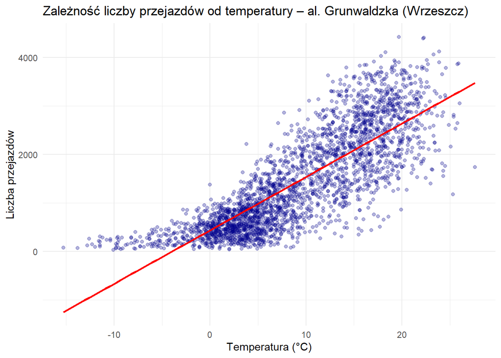

```r
wybrana_stacja <- "al. Grunwaldzka (Wrzeszcz)"

dane %>%
  filter(Stacja == wybrana_stacja) %>%
  ggplot(aes(x = Temperatura, y = Licznik)) +
  geom_point(alpha = 0.3, color = "darkblue") +
  geom_smooth(method = "lm", se = FALSE, color = "red") +
  labs(title = paste("Zależność liczby przejazdów od temperatury –", wybrana_stacja),
       x = "Temperatura (°C)", y = "Liczba przejazdów") +
  theme_minimal()
```

**Wnioski**

- Liczba przejazdów wzrasta wraz ze wzrostem temperatury, co sugeruje silny pozytywny wpływ warunków pogodowych na aktywność rowerową na tej stacji.
- Przy niższych temperaturach (poniżej 0°C) liczba przejazdów jest znacznie mniejsza, co wskazuje na ograniczenia związane z zimową aurą.
- Najwyższe wartości przejazdów występują w zakresie temperatur od 10°C do 20°C, co może wskazywać na optymalne warunki dla rowerzystów.
- Linia trendu potwierdza wyraźną zależność między temperaturą a liczbą przejazdów, sugerując, że wyższe temperatury sprzyjają większej frekwencji na stacji Al. Grunwaldzka (Wrzeszcz).
- Rozproszenie punktów wokół linii trendu wskazuje na pewne wahania, co może być związane z innymi czynnikami, takimi jak wilgotność czy dni robocze/weekendy, ale ogólny trend pozostaje pozytywny.

## 5.2 Ogólne - Wpływ temperatury na liczbę przejazdów

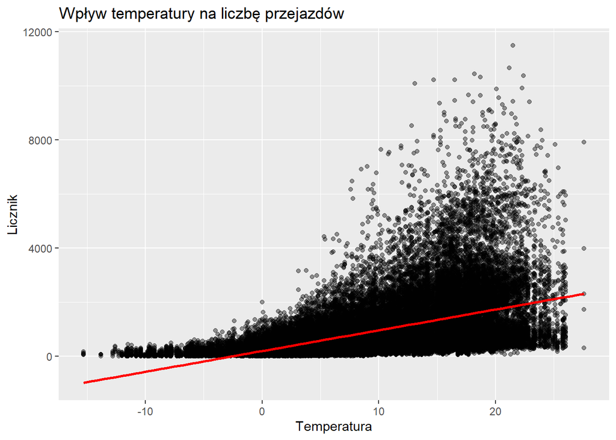

```r
dane %>%
  ggplot(aes(x = Temperatura, y = Licznik)) +
  geom_point(alpha = 0.4) +
  geom_smooth(method = "lm", color = "red") +
  labs(title = "Wpływ temperatury na liczbę przejazdów")
```

- Przy temperaturach poniżej 0°C liczba przejazdów jest bardzo niska, zazwyczaj poniżej 1000, a często bliska 0, co wskazuje na minimalny ruch rowerowy w zimnych warunkach.
- Wraz ze wzrostem temperatury od 0°C do 10°C, liczba przejazdów rośnie, osiągając wartości od 1000 do 4000, choć rozrzut danych jest duży.
- Przy temperaturach między 10°C a 20°C obserwuje się największe natężenie ruchu, z liczbą przejazdów często przekraczającą 4000, a w niektórych przypadkach sięgającą 8000–12 000. Gęstość punktów w tym zakresie jest najwyższa.
- Powyżej 20°C liczba przejazdów nadal jest wysoka, ale rozrzut danych maleje, a maksymalne wartości rzadko przekraczają 10 000 przejazdów.
- Linia trendu (czerwona) pokazuje wyraźny wzrost liczby przejazdów wraz z temperaturą, co potwierdza pozytywną korelację między tymi zmiennymi.

**Wnioski:**

Wykres wskazuje, że temperatura ma istotny wpływ na ruch rowerowy w Gdańsku. Największe natężenie występuje w temperaturach między 10°C a 20°C, co odpowiada wiosennym i letnim warunkom. Niskie temperatury (poniżej 0°C) znacząco ograniczają ruch, co jest zgodne z oczekiwaniami dotyczącymi wpływu pogody na aktywność rowerową.